**Mediation Results** based on Bayesian models

Is the **Treatment** Effect on **DLQI** mediated?<sup>1</sup>

Mediator

Direct

Indirect

Viz(Effect)  
− ←‒‒‒‒‒‒ 0 → +

Proportion  
Mediated<sup>2</sup>

Viz(Mediated)  
− ←‒ 0 ‒→ +

Analyses w/ LOCF<sup>3</sup>

Itch<sup>4</sup>

−1.1  
(−2.3, 0.19)

−3.8  
(−5.6, −2.1)

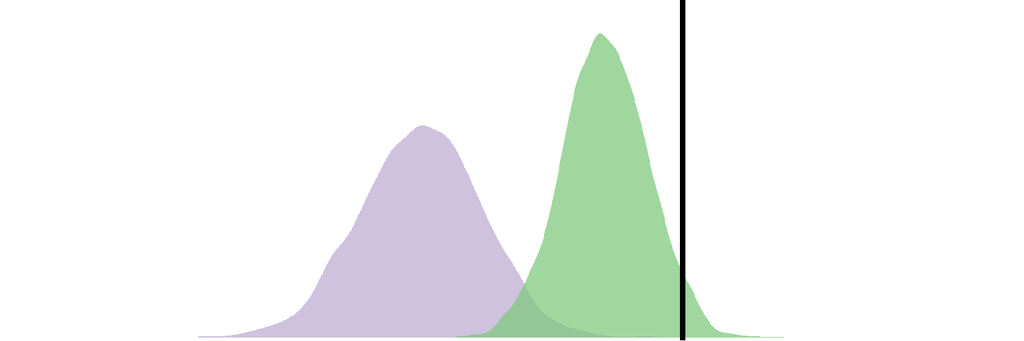

0.77  
(0.54, 1.0)

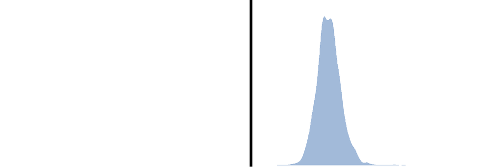

Redness<sup>4</sup>

−6.6  
(−10, −3.4)

1.6  
(−0.87, 4.3)

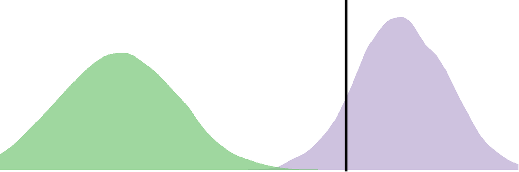

−0.33  
(−0.92, 0.27)

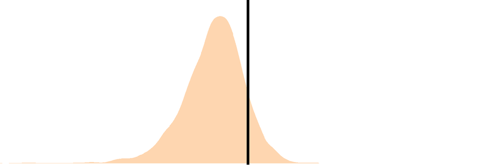

BSA<sup>5</sup>

−6.6  
(−10, −3.2)

1.6  
(−1.3, 4.3)

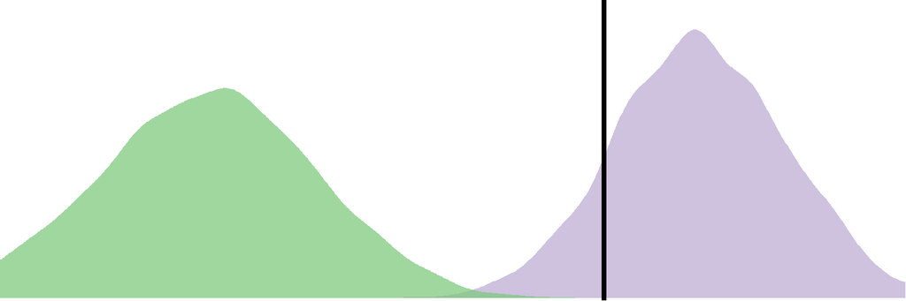

−0.33  
(−0.96, 0.31)

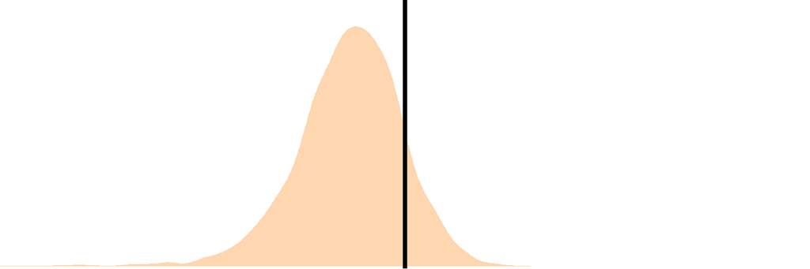

Analyses w/ Observed

Itch<sup>4</sup>

−1.1  
(−2.5, 0.21)

−3.1  
(−5.2, −1.2)

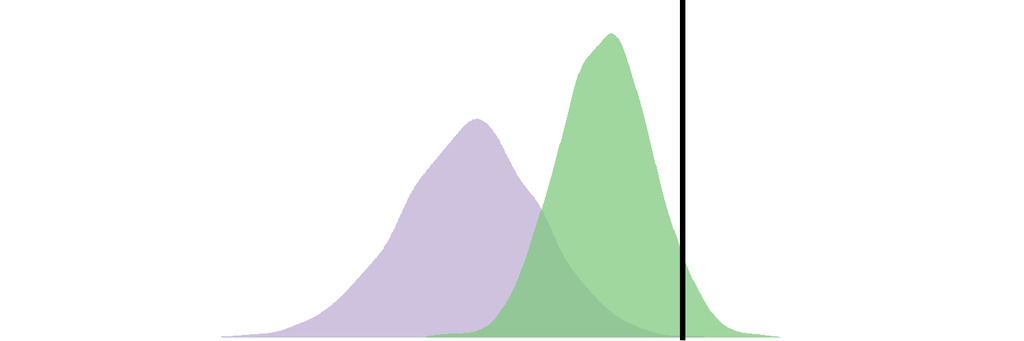

0.73  
(0.41, 1.1)

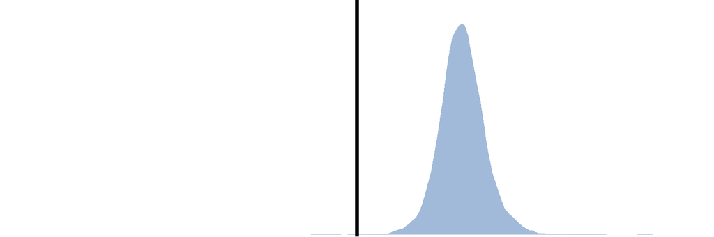

Redness<sup>4</sup>

−5.2  
(−8.9, −1.4)

0.62  
(−2.4, 3.6)

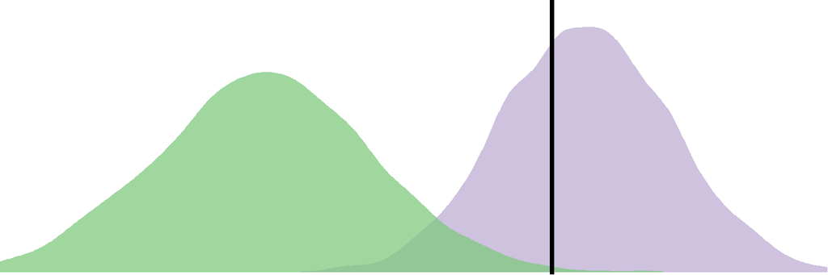

−0.14  
(−0.90, 0.63)

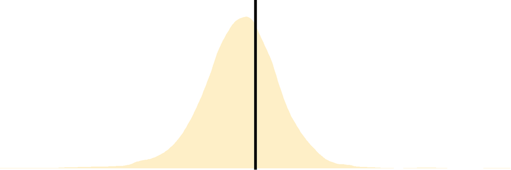

BSA<sup>5</sup>

−5.7  
(−9.4, −2.2)

1.3  
(−1.4, 4.1)

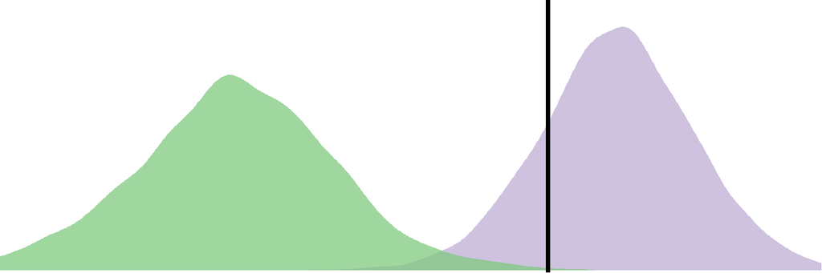

−0.28  
(−1.0, 0.46)

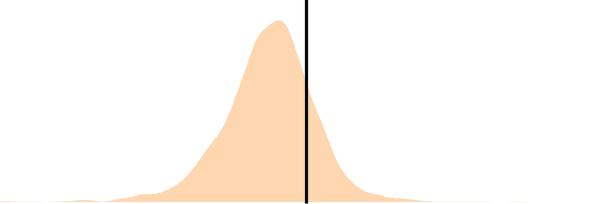

**DIRECT**

[figure not shown]

**INDIRECT**

[figure not shown]

<sup>*1*</sup> Dermatology Life Quality Index (DLQI) at 24 weeks. DLQI ranges from 0 to 30 the lower score the better

<sup>*2*</sup> Proportion Mediated: is the ratio of the INDIRECT effect to the total effect ( DIRECT + INDIRECT )

<sup>*3*</sup> Missing data was imputed using Last Observation Carried Forward (LOCF)

<sup>*4*</sup> Patient self report daily, ranges from 0-10 and averaged every week. The lower the score the better

<sup>*5*</sup> Physician measure, ranges from 0-100%. The lower the score the better